# Visualização de Dados com o ggoplot2

- Você pode aprender qual estatística um geom usa inspecionando o valor padrão para o argumento stat.
  - Por exemplo, *?geom_bar* mostra que o valor padrão para *stat* é “count”, o que significa que *geom_bar()* usa *stat_count()*.
  - `stat_count()` está documentado na mesma página que `geom_bar()`, e se você rolar para baixo, poderá encontrar uma seção chamada “Variáveis calculadas”. Isso descreve como ele calcula duas novas variáveis: count e prop.
- Você geralmente pode usar geoms e estatísticas de forma intercambiável. Por exemplo, você pode recriar o gráfico anterior usando `stat_count()` em vez de `geom_bar()`:

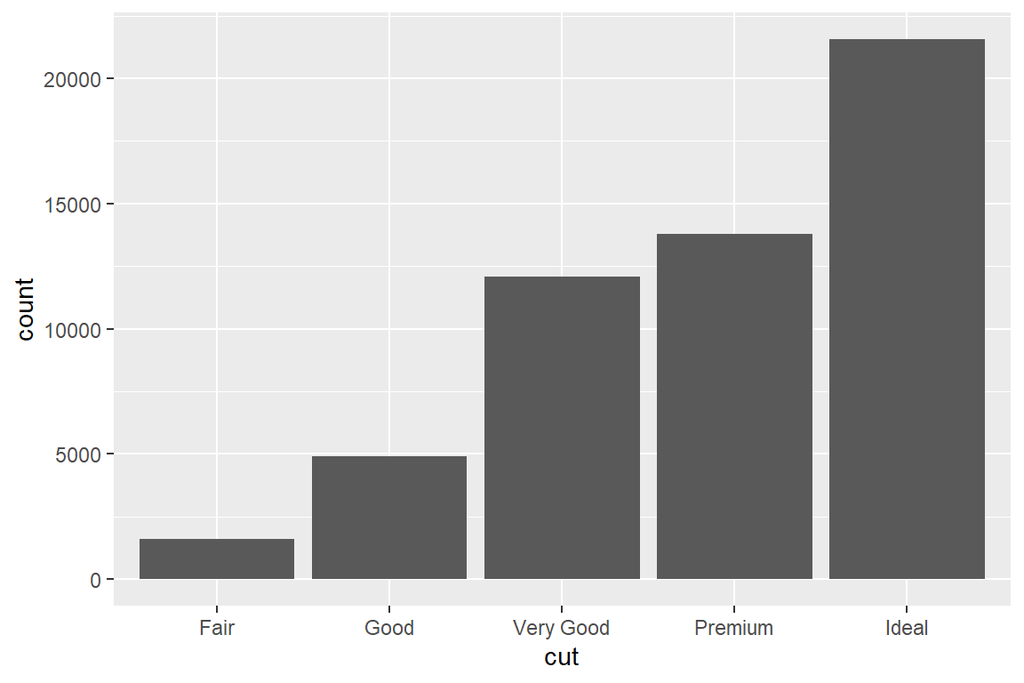

```r
ggplot(data = diamonds) +
  stat_count(mapping = aes(x = cut))
```

- Isso funciona porque cada geom tem uma estatística padrão; e cada estatística tem um geom padrão.
- Há três razões pelas quais você pode precisar usar uma estatística explicitamente:
  - Você pode querer substituir a estatística padrão. No código abaixo, altera-se a `stat count` de `geom_bar()` para identity. Isso permite mapear a altura das barras para os valores brutos de uma variável.

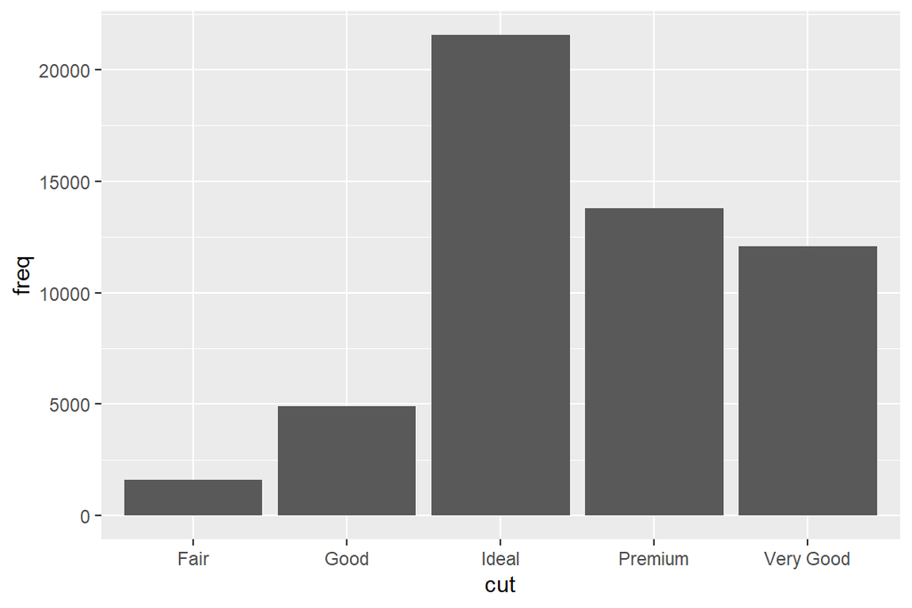

```r
demo <- tribble(
  ~cut,         ~freq,
  "Fair",       1610,
  "Good",       4906,
  "Very Good",  12082,
  "Premium",    13791,
  "Ideal",      21551
)

ggplot(data = demo) +
  geom_bar(mapping = aes(x = cut, y = freq), stat = "identity")
```

- Você pode querer substituir o mapeamento padrão de variáveis transformadas para estética. Por exemplo, talvez você queira exibir um gráfico de barras de proporção, em vez de contar:

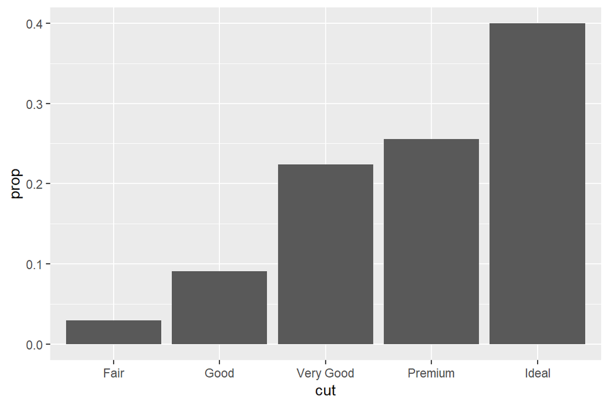

```r
ggplot(data = diamonds) +
  geom_bar(mapping = aes(x = cut, y = stat(prop), group = 1))
```

- Você pode querer chamar mais atenção para a transformação estatística em seu código. Por exemplo, você pode usar stat_summary(), que resume os valores y para cada valor x exclusivo, para chamar a atenção para o resumo que você está calculando:

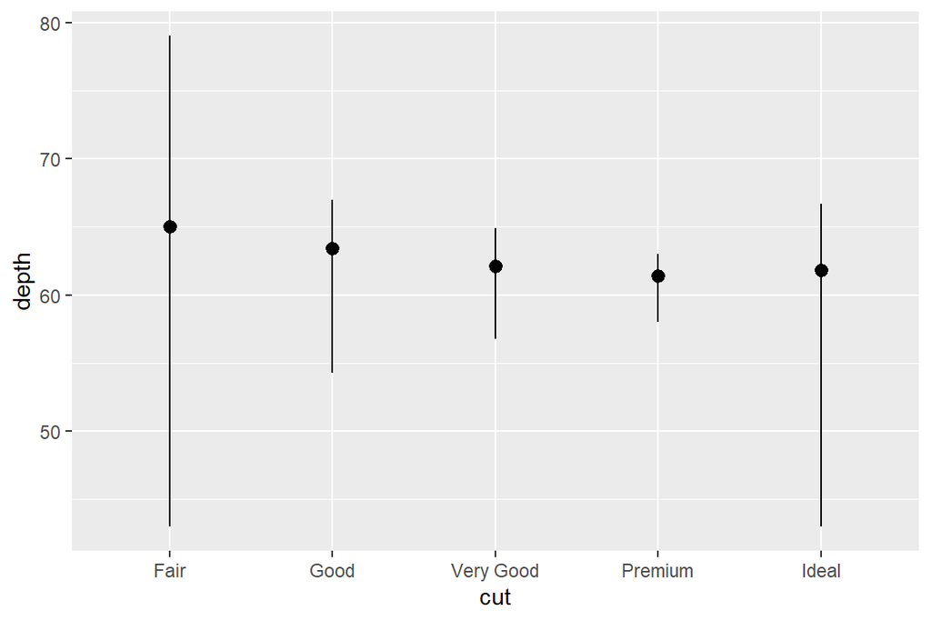

```r
ggplot(data = diamonds) +
  stat_summary(
    mapping = aes(x = cut, y = depth),
    fun.min = min,
    fun.max = max,
    fun = median
  )
```

Outros exemplos:

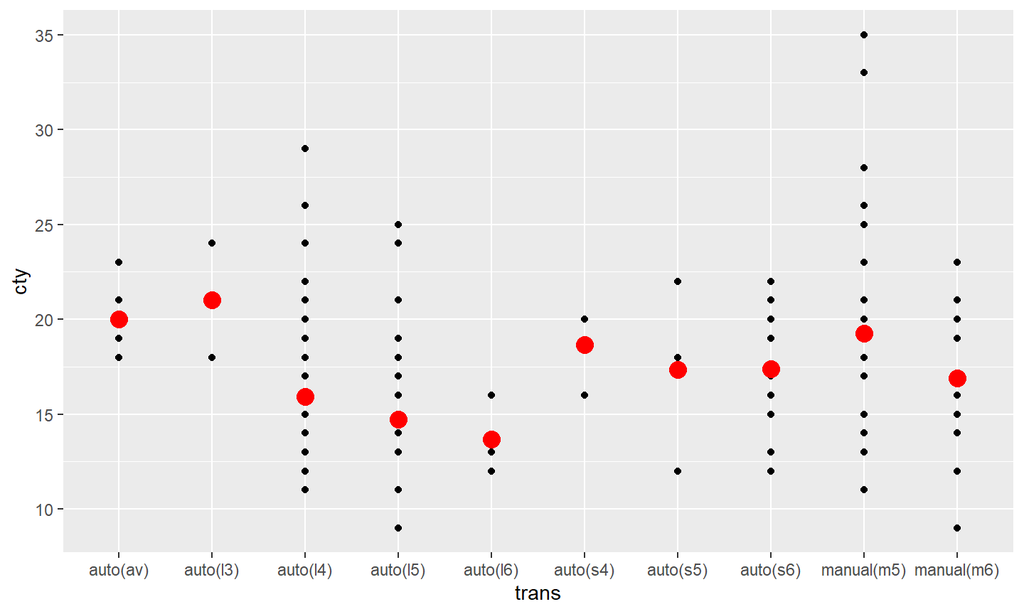

```r
ggplot(mpg, aes(trans, cty)) +
  geom_point() +
  stat_summary(geom = "point", fun.y = "mean", colour = "red", size = 4)
```

```r
df <- data.frame(dose=c("D0.5", "D1", "D2","D0.5", "D1", "D2"),
                 len=c(4.2, 10, 29.5,5,15,36))

head(df)
```

```
##   dose  len
## 1 D0.5  4.2
## 2   D1 10.0
## 3   D2 29.5
## 4 D0.5  5.0
## 5   D1 15.0
## 6   D2 36.0
```

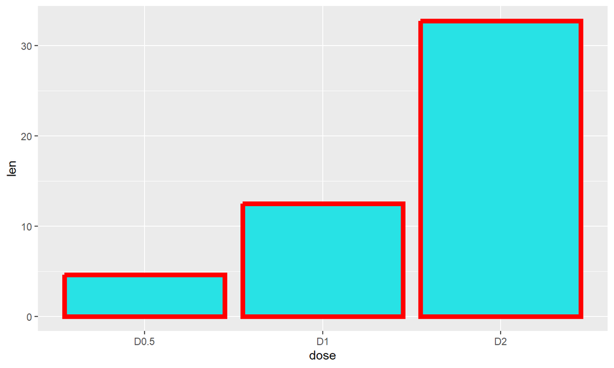

```r
ggplot(data=df, aes(x=dose, y=len)) +
  stat_summary(geom = "bar", fun.y = "mean", colour = "red", size = 2, fill=5)
```

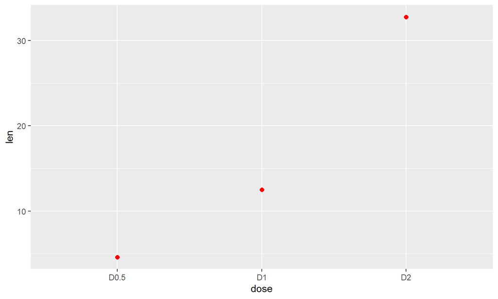

```r
ggplot(data=df, aes(x=dose, y=len)) +
  stat_summary(geom = "point", fun.y = "mean", colour = "red", size = 2, fill=5)
```

- ggplot2 fornece mais de 20 estatísticas para você usar.
  - Cada estatística é uma função, então você pode obter ajuda da maneira usual, por exemplo ?stat_bin.
  - Para ver uma lista completa de estatísticas, experimente a folha de dicas do `ggplot2`.

## Ajustes de posição

Há mais uma mágica associada aos gráficos de barras. Você pode colorir um gráfico de barras usando a estética colour ou, mais útil, **fill**:

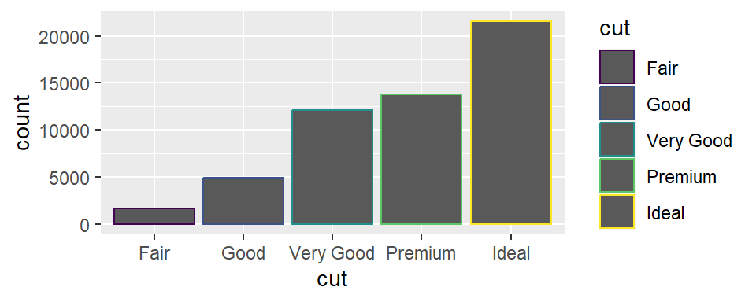

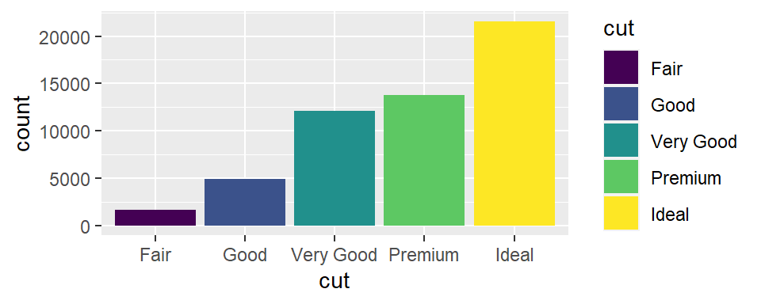

```r
ggplot(data = diamonds) +
  geom_bar(mapping = aes(x = cut, color = cut))
ggplot(data = diamonds) +
  geom_bar(mapping = aes(x = cut, fill = cut))
```

Observe o que acontece se você mapear a estética de preenchimento para outra variável, como `clarity`: as barras são empilhadas automaticamente.

```
- Cada retângulo colorido representa uma combinação de `cute` e `clarity`.
```

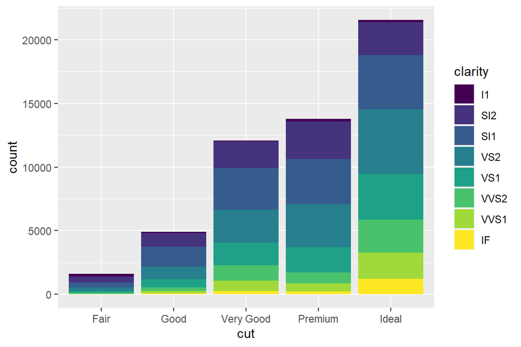

```r
ggplot(data = diamonds) +
  geom_bar(mapping = aes(x = cut, fill = clarity))
```

O empilhamento é realizado automaticamente pelo ajuste de posição especificado pelo argumento position.

```
- Se não quiser um gráfico de barras empilhadas, você pode usar uma das três outras opções: "identity", "dodge" ou "fill".
```

- position = “identity” colocará cada objeto exatamente onde ele cai no contexto do gráfico.
  - Isso não é muito útil para barras, porque as sobrepõe.
  - Para ver essa sobreposição, precisamos tornar as barras ligeiramente transparentes definindo `alpha` um valor pequeno ou completamente transparentes definindo `fill = NA`.

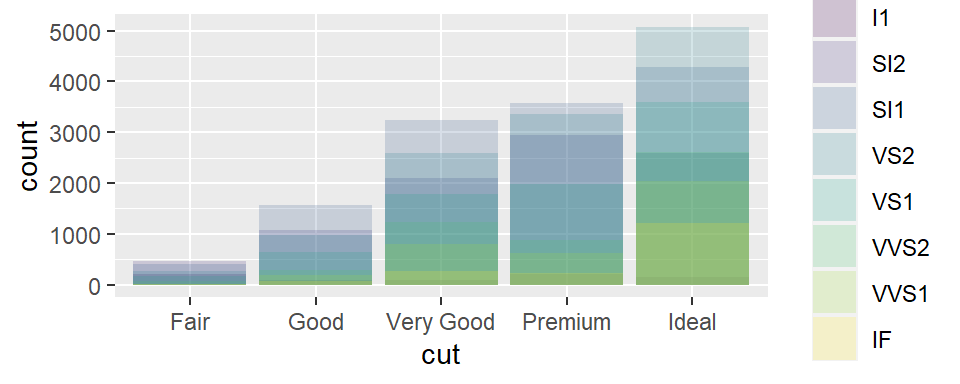

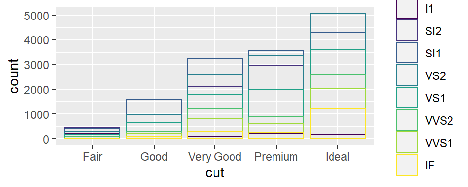

```r
ggplot(data = diamonds, mapping = aes(x = cut, fill = clarity)) +
  geom_bar(alpha = 1/5, position = "identity")
ggplot(data = diamonds, mapping = aes(x = cut, color = clarity)) +
  geom_bar(fill = NA, position = "identity")
```

O ajuste da posição de identidade é mais útil para geometrias 2D, como pontos, onde é o padrão.

- position = “fill” funciona como empilhamento, mas faz com que cada conjunto de barras empilhadas tenha a mesma altura. Isso facilita a comparação de proporções entre grupos.

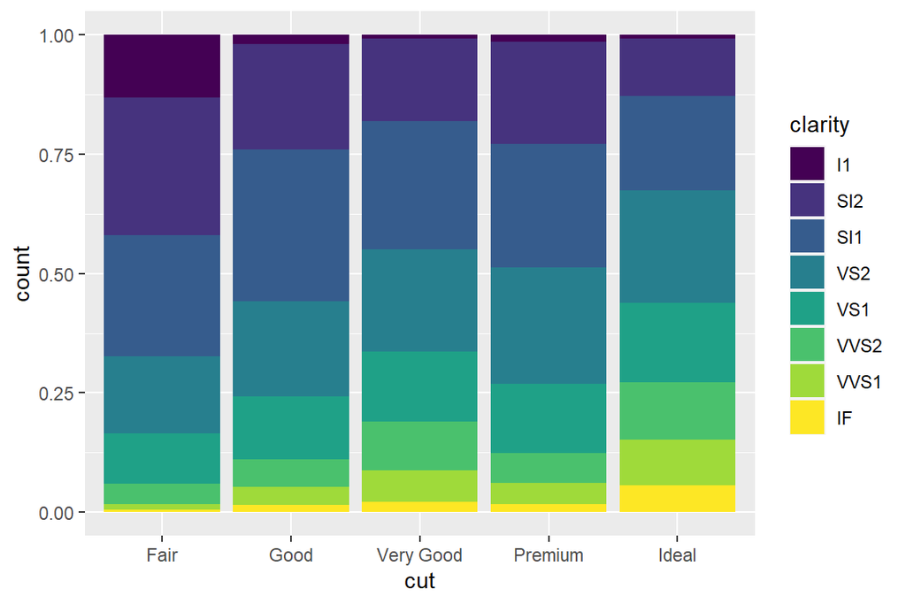

```r
ggplot(data = diamonds) +
  geom_bar(mapping = aes(x = cut, fill = clarity), position = "fill")
```

- position = “dodge” coloca objetos sobrepostos diretamente um ao lado do outro. Isso facilita a comparação de valores individuais.

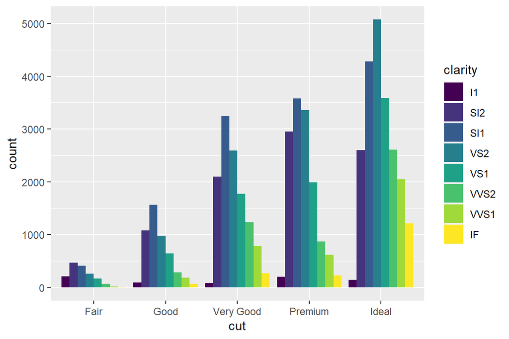

```r
ggplot(data = diamonds) +
  geom_bar(mapping = aes(x = cut, fill = clarity), position = "dodge")
```

Há um outro tipo de ajuste que não é útil para gráficos de barras, mas pode ser muito útil para gráficos de dispersão.

Você pode evitar essa grade configurando o ajuste de posição para **“jitter”**.

- position = “jitter” adiciona uma pequena quantidade de ruído aleatório a cada ponto.
  - Isso espalha os pontos porque dois pontos provavelmente não receberão a mesma quantidade de ruído aleatório.

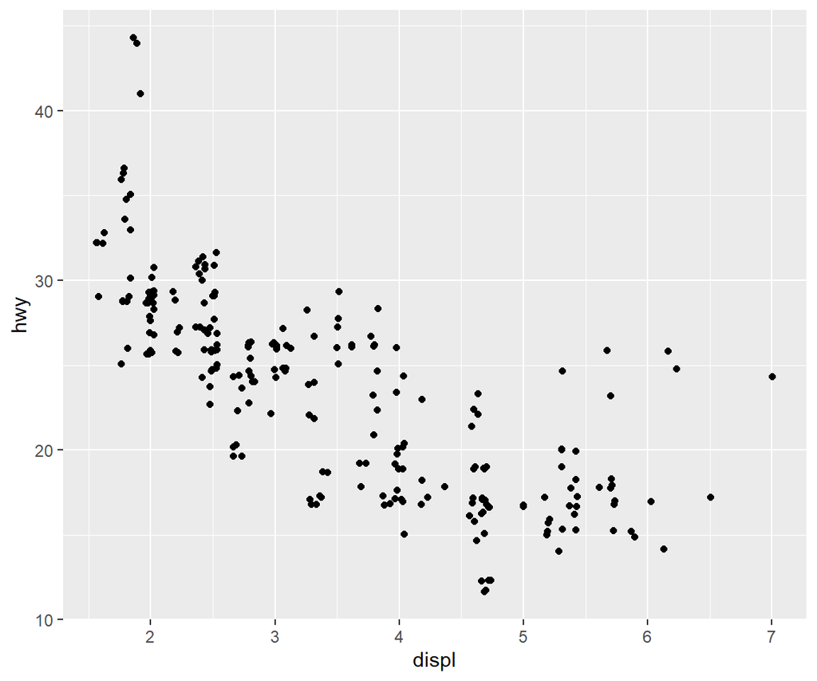

```r
ggplot(data = mpg) +
  geom_point(mapping = aes(x = displ, y = hwy), position = "jitter")
```

Adicionar aleatoriedade parece uma maneira estranha de melhorar seu gráfico, mas, embora torne seu gráfico menos preciso em pequenas escalas, torna seu gráfico mais revelador em grandes escalas.

- Por ser uma operação tão útil, *ggplot2* vem com um atalho para *geom_point(position = “jitter”)*: *geom_jitter()*.

Para saber mais sobre um ajuste de posição, consulte a página de ajuda associada a cada ajuste: `?position_dodge, ?position_fill, ?position_identity, ?position_jittere ?position_stack.`

## Sistemas de coordenadas

Os sistemas de coordenadas são provavelmente a parte mais complicada do `ggplot2`.

- O sistema de coordenadas padrão é o sistema de coordenadas cartesianas onde as posições x e y atuam independentemente para determinar a localização de cada ponto.

Existem vários outros sistemas de coordenadas que ocasionalmente são úteis.

- **coord_flip()** alterna os eixos x e y. Isso é útil (por exemplo), se você quiser boxplots horizontais. Também é útil para rótulos longos: é difícil encaixá-los sem sobrepor no eixo x.

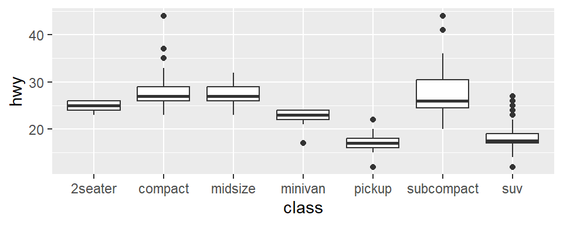

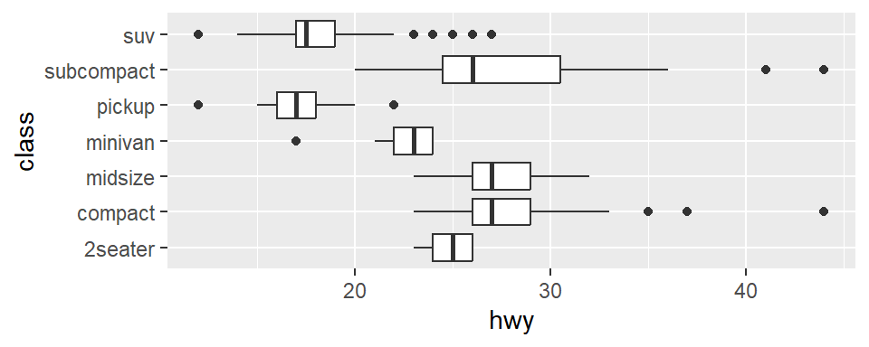

```r
ggplot(data = mpg, mapping = aes(x = class, y = hwy)) +
  geom_boxplot()
ggplot(data = mpg, mapping = aes(x = class, y = hwy)) +
  geom_boxplot() +
  coord_flip()
```

- **coord_quickmap()** define a proporção de aspecto corretamente para mapas. Isso é muito importante se você estiver plotando dados espaciais com ggplot2

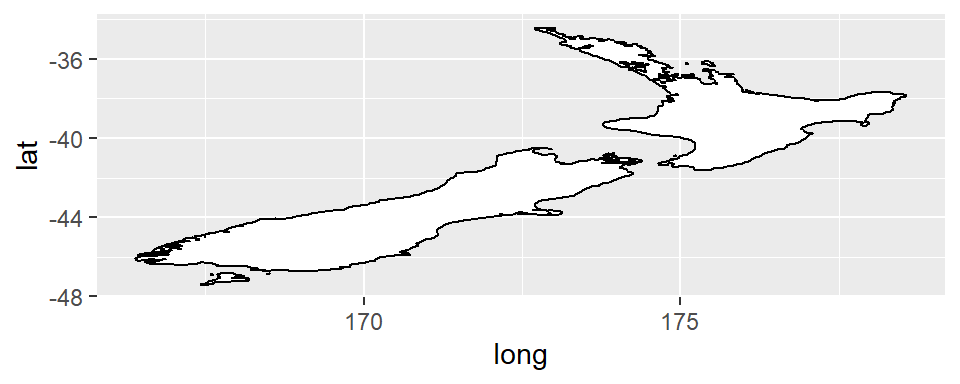

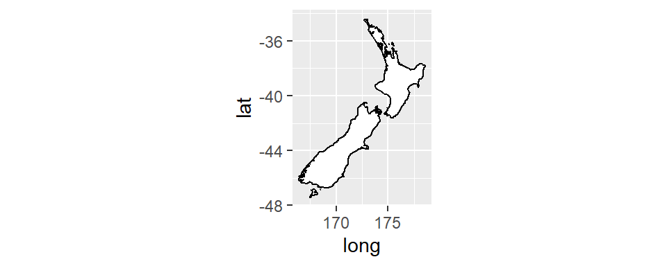

```r
nz <- map_data("nz")

ggplot(nz, aes(long, lat, group = group)) +
  geom_polygon(fill = "white", color = "black")

ggplot(nz, aes(long, lat, group = group)) +
  geom_polygon(fill = "white", color = "black") +
  coord_quickmap()
```

- **coord_polar()** usa coordenadas polares. As coordenadas polares revelam uma conexão interessante entre um gráfico de barras e um gráfico Coxcomb.

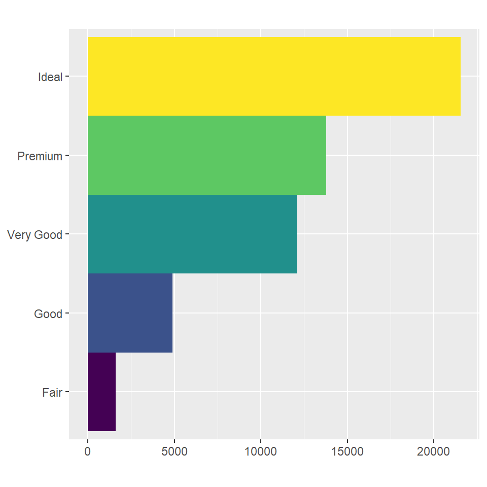

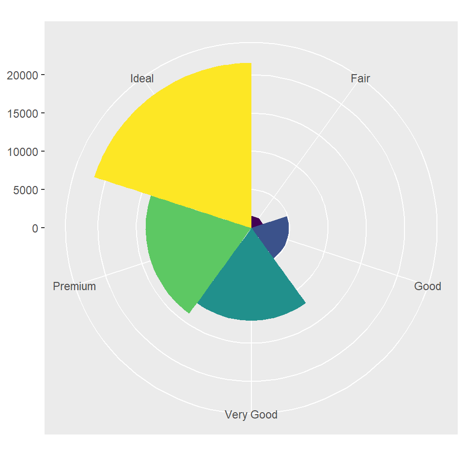

```r
bar <- ggplot(data = diamonds) +
  geom_bar(
    mapping = aes(x = cut, fill = cut),
    show.legend = FALSE,
    width = 1
  ) +
  theme(aspect.ratio = 1) +
  labs(x = NULL, y = NULL)

bar + coord_flip()
bar + coord_polar()
```

## A gramática em camadas de gráficos

Vamos adicionar ajustes de posição, estatísticas, sistemas de coordenadas e facetas ao nosso modelo de código:

```
ggplot(data = <DATA>) +
  <GEOM_FUNCTION>(
     mapping = aes(<MAPPINGS>),
     stat = <STAT>,
     position = <POSITION>
  ) +
  <COORDINATE_FUNCTION> +
  <FACET_FUNCTION>
```

Na prática, você raramente precisa fornecer todos os sete parâmetros para fazer um gráfico porque o `ggplot2` fornecerá padrões úteis para tudo, exceto os dados, os mapeamentos e a função geom.

- Os sete parâmetros do template compõem a gramática dos gráficos.
- A gramática dos gráficos é baseada na percepção de que você pode descrever exclusivamente qualquer gráfico como uma combinação de um conjunto de dados, uma geometria, um conjunto de mapeamentos, uma estatística, um ajuste de posição, um sistema de coordenadas e um esquema de facetas.

## Labels

O lugar mais fácil para começar ao transformar um gráfico exploratório em um gráfico expositivo é com bons rótulos.

- Você adiciona rótulos com a função [`labs()`](https://ggplot2.tidyverse.org/reference/labs.html).
- Este exemplo adiciona um título de plotagem:

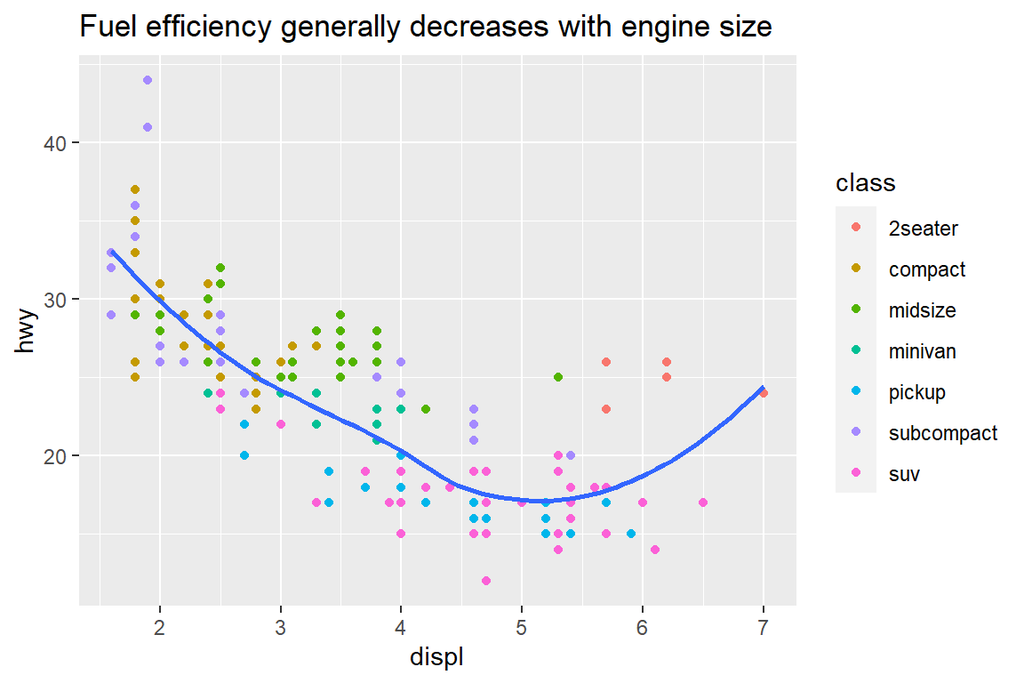

```r
    ggplot(mpg, aes(displ, hwy)) +
      geom_point(aes(color = class)) +
      geom_smooth(se = FALSE) +
      labs(title = "Fuel efficiency generally decreases with engine size")
```

Se você precisar adicionar mais texto, há dois outros rótulos úteis que você pode usar no ggplot2:

- `subtitle` adiciona detalhes adicionais em uma fonte menor abaixo do título.
- `caption` adiciona texto no canto inferior direito do gráfico, geralmente usado para descrever a fonte dos dados.

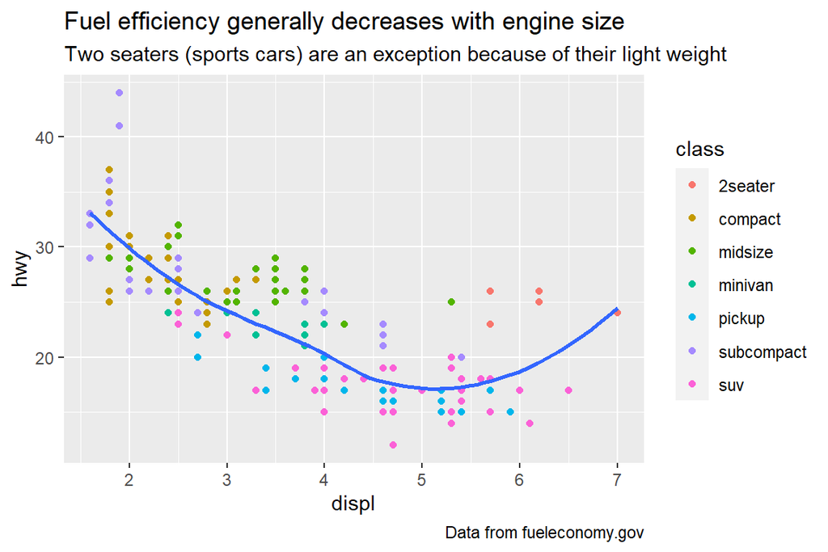

```r
    ggplot(mpg, aes(displ, hwy)) +
      geom_point(aes(color = class)) +
      geom_smooth(se = FALSE) +
      labs(
        title = "Fuel efficiency generally decreases with engine size",
        subtitle = "Two seaters (sports cars) are an exception because of their light weight",
        caption = "Data from fueleconomy.gov"
      )
```

Você também pode usar [`labs()`](https://ggplot2.tidyverse.org/reference/labs.html) para substituir os títulos dos eixos e legendas.

- Geralmente, é uma boa ideia substituir nomes de variáveis curtos por descrições mais detalhadas e incluir as unidades.

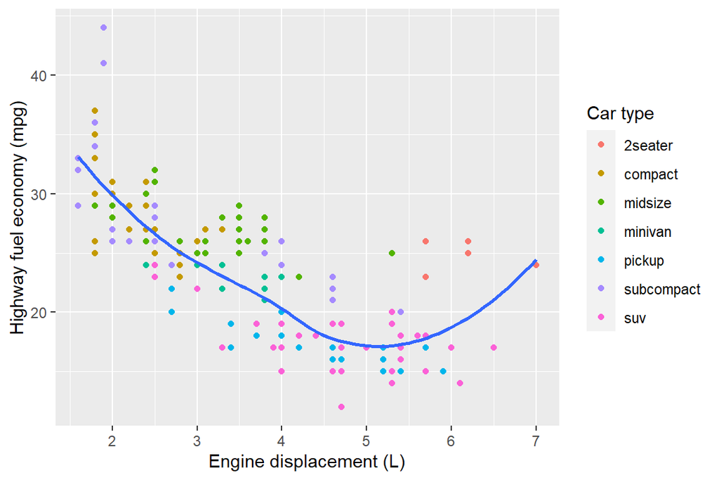

```r
    ggplot(mpg, aes(displ, hwy)) +
      geom_point(aes(colour = class)) +
      geom_smooth(se = FALSE) +
      labs(
        x = "Engine displacement (L)",
        y = "Highway fuel economy (mpg)",
        colour = "Car type"
      )
```

É possível usar equações matemáticas em vez de strings de texto.

- Basta utilizar `quote()`

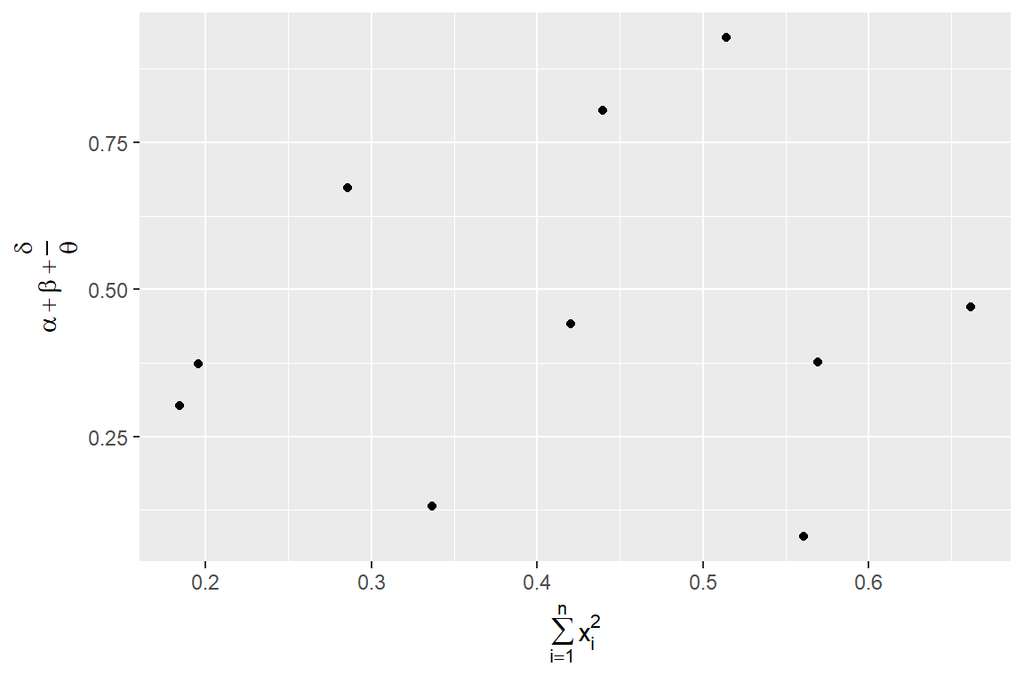

```r
    df <- tibble(
      x = runif(10),
      y = runif(10)
    )
    ggplot(df, aes(x, y)) +
      geom_point() +
      labs(
        x = quote(sum(x[i] ^ 2, i == 1, n)),
        y = quote(alpha + beta + frac(delta, theta))
      )
```

## Escalas

A terceira maneira de tornar seu plot melhor para comunicação é ajustar as escalas.

- As escalas controlam o mapeamento de valores de dados para coisas que você pode perceber.
- Normalmente, o ggplot2 adiciona escalas automaticamente para você.

Por exemplo, quando você digita:

```r
    ggplot(mpg, aes(displ, hwy)) +
      geom_point(aes(colour = class))
```

ggplot2 adiciona automaticamente escalas padrão nos bastidores:

```r
    ggplot(mpg, aes(displ, hwy)) +
      geom_point(aes(colour = class)) +
      scale_x_continuous() +
      scale_y_continuous() +
      scale_colour_discrete()
```

Observe o esquema de nomenclatura das escalas:

- `scale_` seguido do nome da estética, depois `_`, depois o nome da escala.
- As escalas padrão são nomeadas de acordo com o tipo de variável com a qual se alinham: contínua, discreta, data/hora ou data.

Você pode querer substituir os padrões por dois motivos:

- Você pode querer ajustar alguns dos parâmetros da escala padrão.
- Você pode querer substituir a escala completamente e usar um algoritmo completamente diferente.

### Marcas de eixo e chaves de legenda

Existem dois argumentos principais que afetam a aparência dos tiques nos eixos e as chaves na legenda: `breaks` e `labels`.

- As quebras controlam a posição dos ticks ou os valores associados às chaves.
- Rótulos controla o rótulo de texto associado a cada marcação/chave.

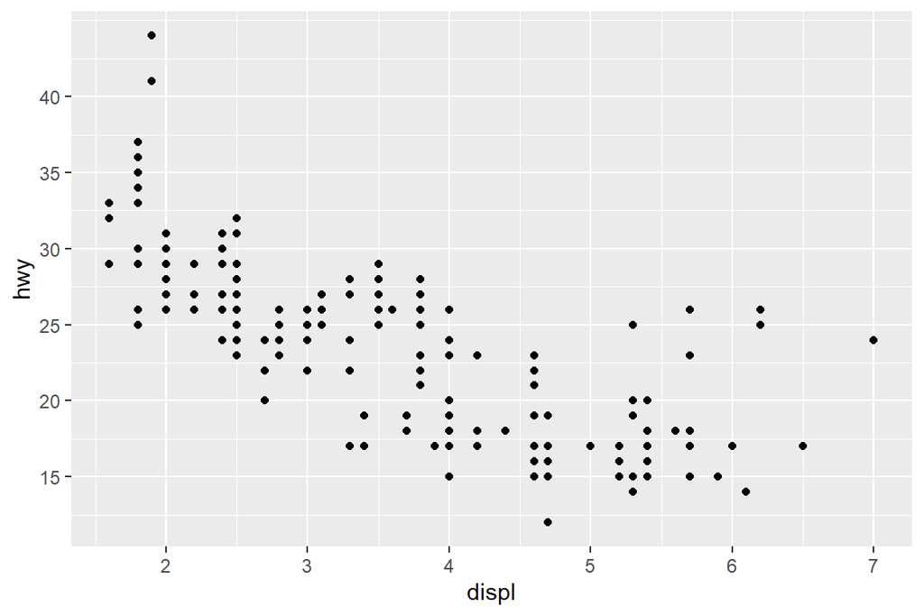

```r
    ggplot(mpg, aes(displ, hwy)) +
      geom_point() +
      scale_y_continuous(breaks = seq(15, 40, by = 5))
```

Você pode usar `labels` da mesma maneira (um vetor de caractere com o mesmo comprimento que `breaks`), mas também pode configurá-lo `NULL` para suprimir os rótulos completamente.

- Isso é útil para mapas ou para publicar gráficos onde você não pode compartilhar os números absolutos.

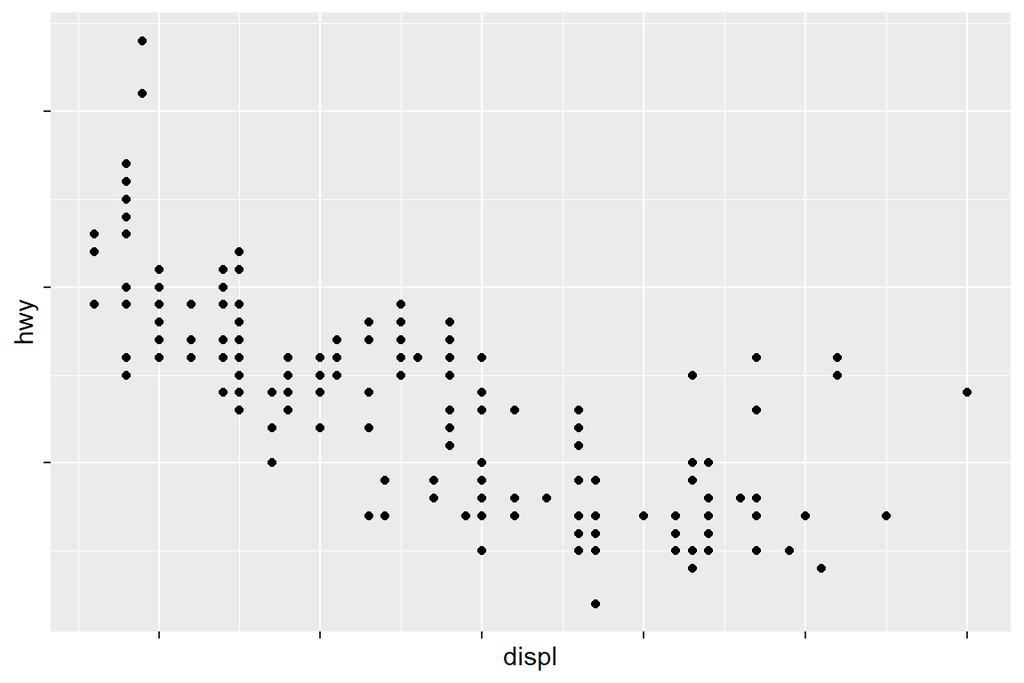

```r
    ggplot(mpg, aes(displ, hwy)) +
      geom_point() +
      scale_x_continuous(labels = NULL) +
      scale_y_continuous(labels = NULL)
```

### Layout da legenda

Para controlar a posição geral da legenda, você precisa usar uma configuração [`theme()`](https://ggplot2.tidyverse.org/reference/theme.html).

- A configuração do tema `legend.position` controla onde a legenda é desenhada:

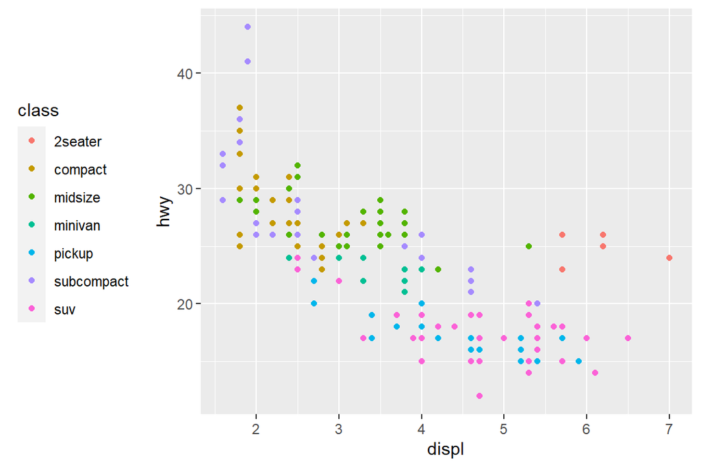

```r
    base <- ggplot(mpg, aes(displ, hwy)) +
      geom_point(aes(colour = class))

    base + theme(legend.position = "left")
```

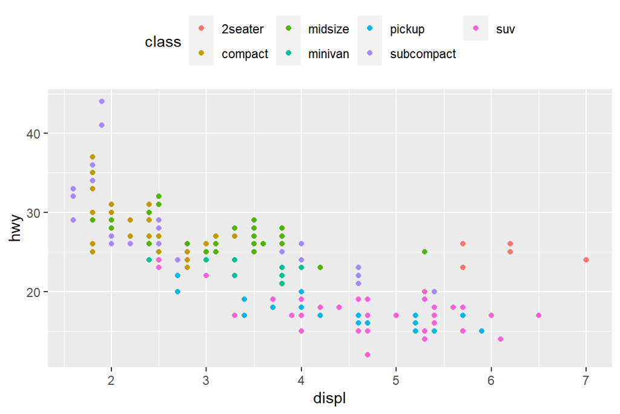

```r
    base + theme(legend.position = "top")
```

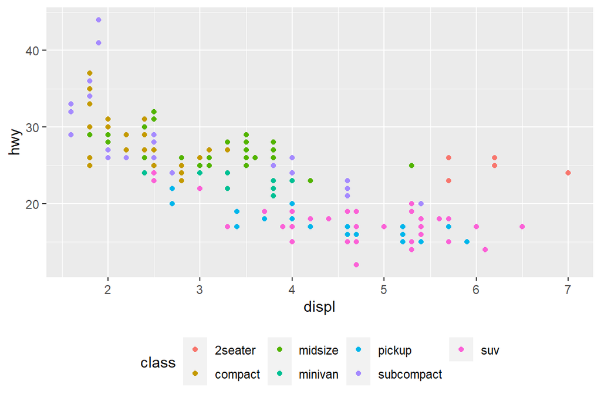

```r
    base + theme(legend.position = "bottom")
```

```r
    base + theme(legend.position = "right")
```

[output not shown]

Você também pode usar `legend.position = "none"` para suprimir completamente a exibição da legenda.

Para controlar a exibição de legendas individuais, use [`guides()`](https://ggplot2.tidyverse.org/reference/guides.html) junto com [`guide_legend()`](https://ggplot2.tidyverse.org/reference/guide_legend.html) ou [`guide_colourbar()`](https://ggplot2.tidyverse.org/reference/guide_colourbar.html).

- O exemplo a seguir mostra duas configurações importantes: controlar o número de linhas que a legenda usa com `nrow` e substituir uma das estéticas para aumentar os pontos.
- Isso é particularmente útil se você tiver usado um ponto baixo `alpha` para exibir muitos pontos em um gráfico.

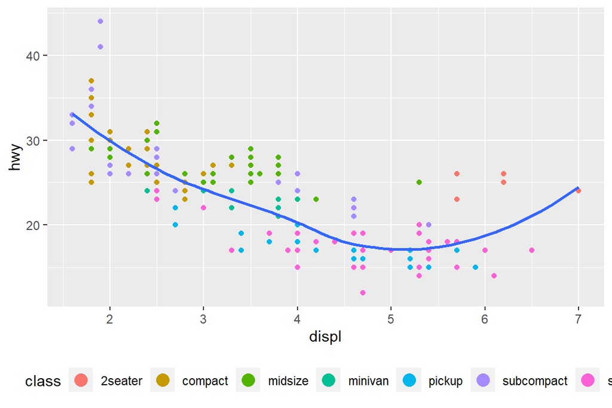

```r
    ggplot(mpg, aes(displ, hwy)) +
      geom_point(aes(colour = class)) +
      geom_smooth(se = FALSE) +
      theme(legend.position = "bottom") +
      guides(colour = guide_legend(nrow = 1, override.aes = list(size = 4)))
```

### Substituindo uma escala

Em vez de apenas ajustar um pouco os detalhes, você pode substituir a escala completamente.

- Existem dois tipos de escalas que você provavelmente deseja trocar: escalas de posição contínuas e escalas de cores.
- Os mesmos princípios se aplicam a todas as outras estéticas.

É muito útil para plotar transformações de sua variável.

- Por exemplo, como vimos nos [preços dos diamantes](https://r4ds.had.co.nz/diamond-prices) , é mais fácil ver a relação precisa entre `carat` e `price`, se transformá-los:

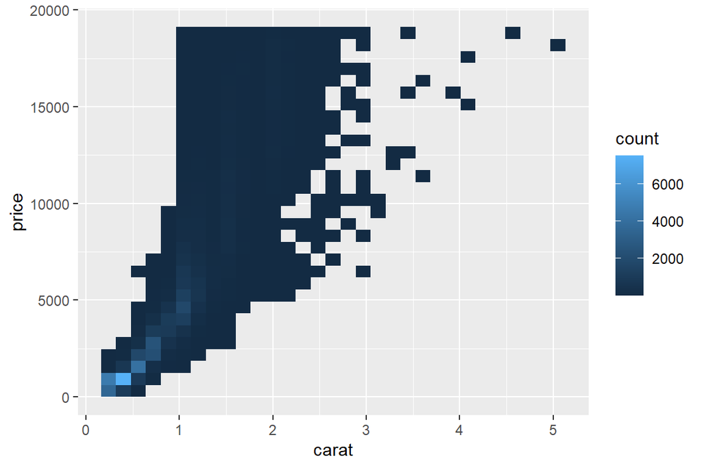

```r
   ggplot(diamonds, aes(carat, price)) +
      geom_bin2d()
```

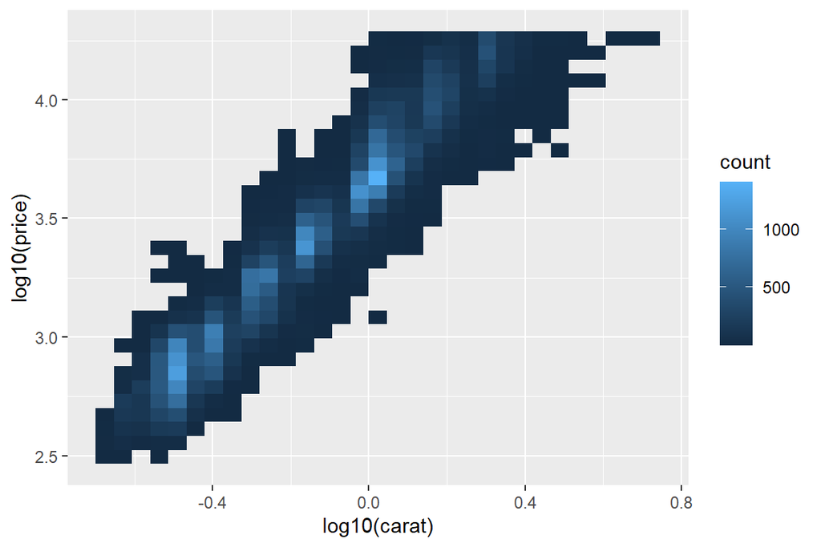

```r
    ggplot(diamonds, aes(log10(carat), log10(price))) +
      geom_bin2d()
```

No entanto, a desvantagem dessa transformação é que os eixos agora são rotulados com os valores transformados, dificultando a interpretação do gráfico.

- Em vez de fazer a transformação no mapeamento estético, podemos fazê-lo com a escala.
- Isso é visualmente idêntico, exceto que os eixos são rotulados na escala de dados original.

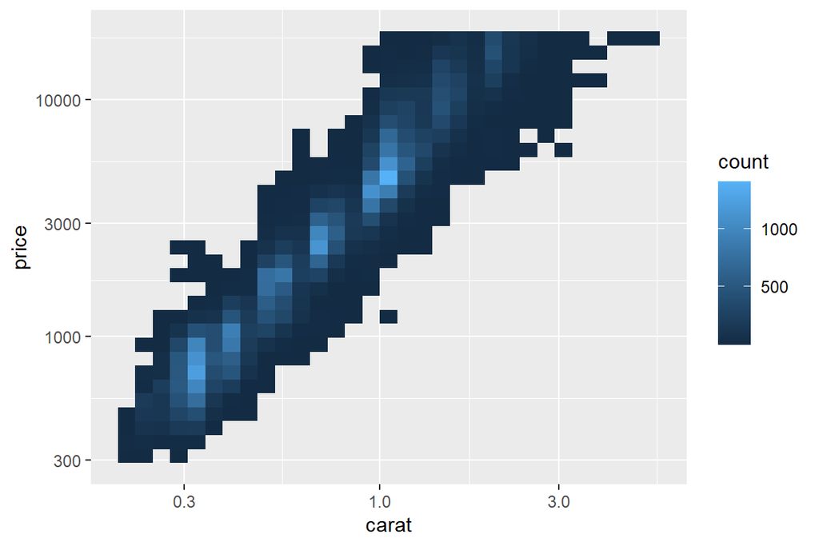

```r
    ggplot(diamonds, aes(carat, price)) +
      geom_bin2d() +
      scale_x_log10() +
      scale_y_log10()
```

Outra escala que é frequentemente customizada é a cor.

- A escala categórica padrão seleciona cores que são espaçadas uniformemente ao redor da roda de cores.
- Alternativas úteis são as escalas ColorBrewer que foram ajustadas manualmente para funcionar melhor para pessoas com tipos comuns de daltonismo.
- As escalas ColorBrewer estão documentadas online em http://colorbrewer2.org/ e disponibilizadas em R através do pacote **RColorBrewer**, por Erich Neuwirth.

Os dois gráficos abaixo parecem semelhantes, mas há diferença suficiente nos tons de vermelho e verde para que os pontos à direita possam ser distinguidos mesmo por pessoas com daltonismo vermelho-verde.

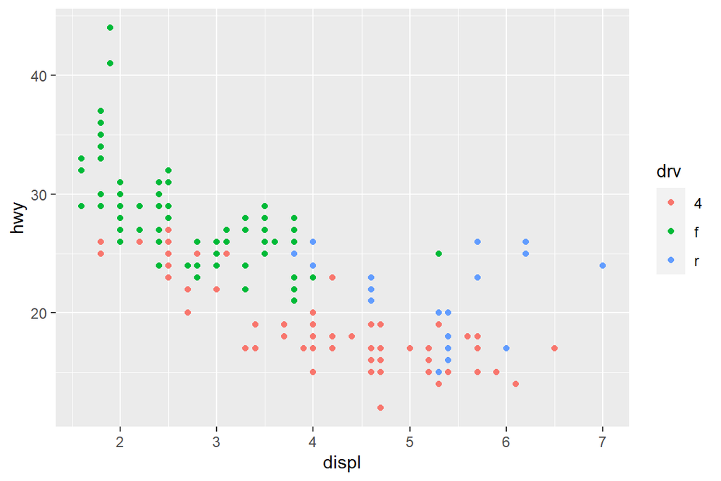

```r
    ggplot(mpg, aes(displ, hwy)) +
      geom_point(aes(color = drv))
```

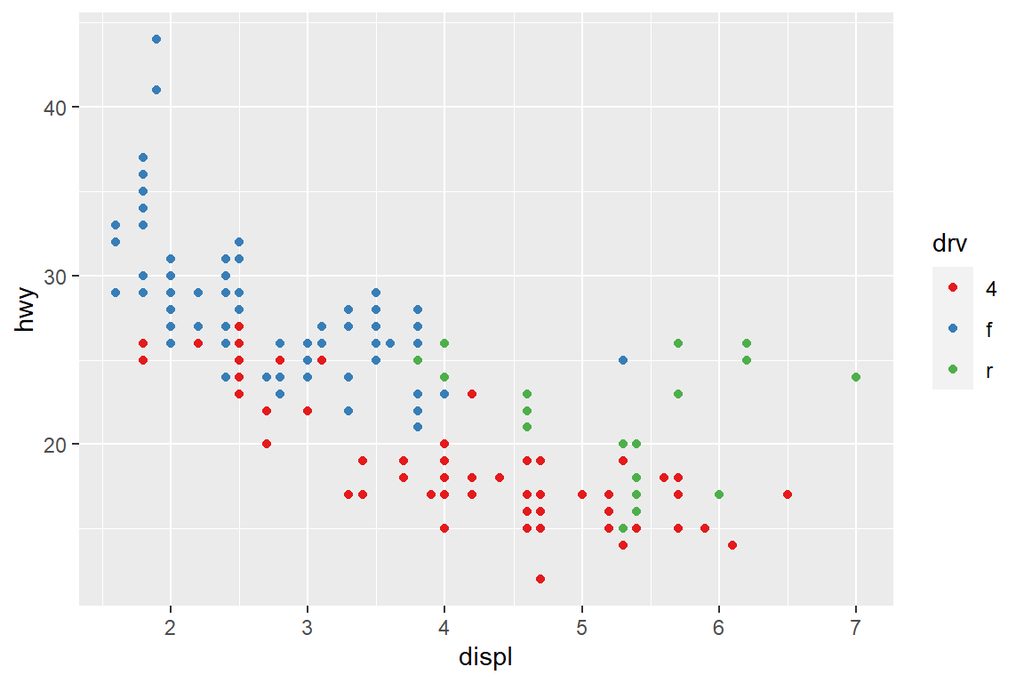

```r
    ggplot(mpg, aes(displ, hwy)) +
      geom_point(aes(color = drv)) +
      scale_colour_brewer(palette = "Set1")
```

Não se esqueça de técnicas mais simples.

- Se houver apenas algumas cores, você pode adicionar um mapeamento de forma redundante.
- Isso também ajudará a garantir que seu gráfico seja interpretável em preto e branco.

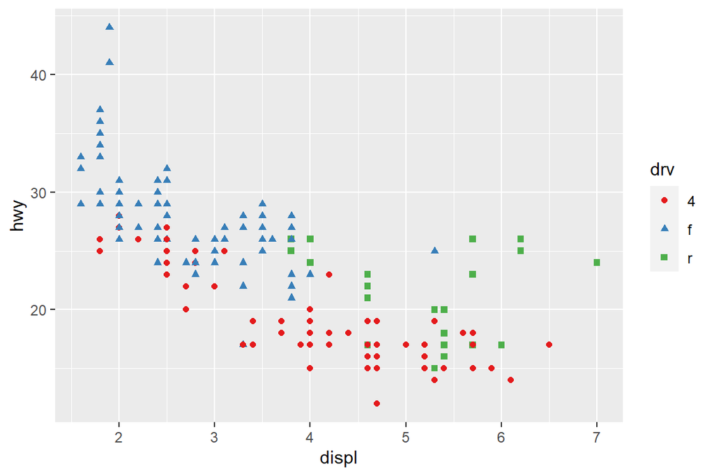

```r
    ggplot(mpg, aes(displ, hwy)) +
      geom_point(aes(color = drv, shape = drv)) +
      scale_colour_brewer(palette = "Set1")
```

Quando você tiver um mapeamento predefinido entre valores e cores, use [`scale_colour_manual()`](https://ggplot2.tidyverse.org/reference/scale_manual.html).

- Por exemplo, se mapearmos a cor do partido presidencial, queremos usar o mapeamento padrão de vermelho para republicanos e azul para democratas:

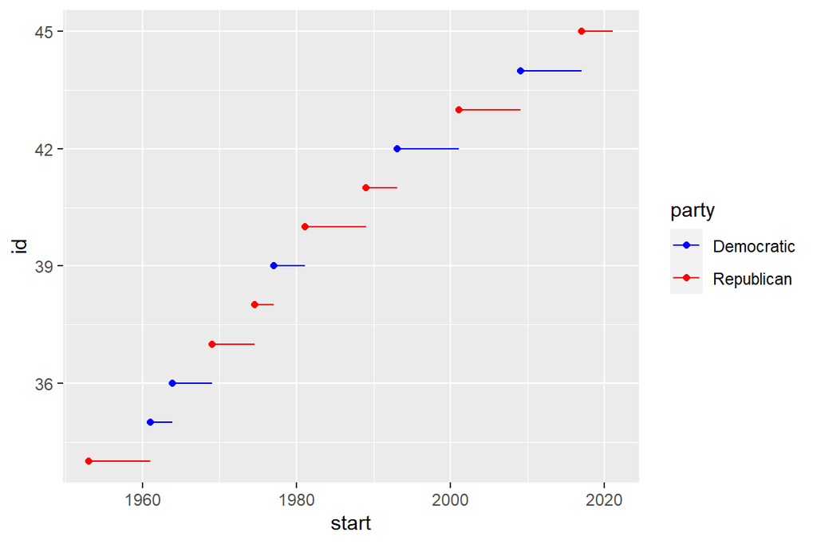

```r
    presidential %>%
      mutate(id = 33 + row_number()) %>%
      ggplot(aes(start, id, colour = party)) +
        geom_point() +
        geom_segment(aes(xend = end, yend = id)) +
        scale_colour_manual(values = c(Republican = "red", Democratic = "blue"))
```

Para cores contínuas, você pode usar [`scale_colour_gradient()`](https://ggplot2.tidyverse.org/reference/scale_gradient.html) o [`scale_fill_gradient()`](https://ggplot2.tidyverse.org/reference/scale_gradient.html).

## Zoom

Existem três maneiras de controlar os limites de plotagem:

1. Ajustando quais dados são plotados
2. Definir os limites em cada escala
3. Configuração `xlim` e `ylim` em [`coord_cartesian()`](https://ggplot2.tidyverse.org/reference/coord_cartesian.html)

Para ampliar uma região do gráfico, geralmente é melhor usar [`coord_cartesian()`](https://ggplot2.tidyverse.org/reference/coord_cartesian.html).

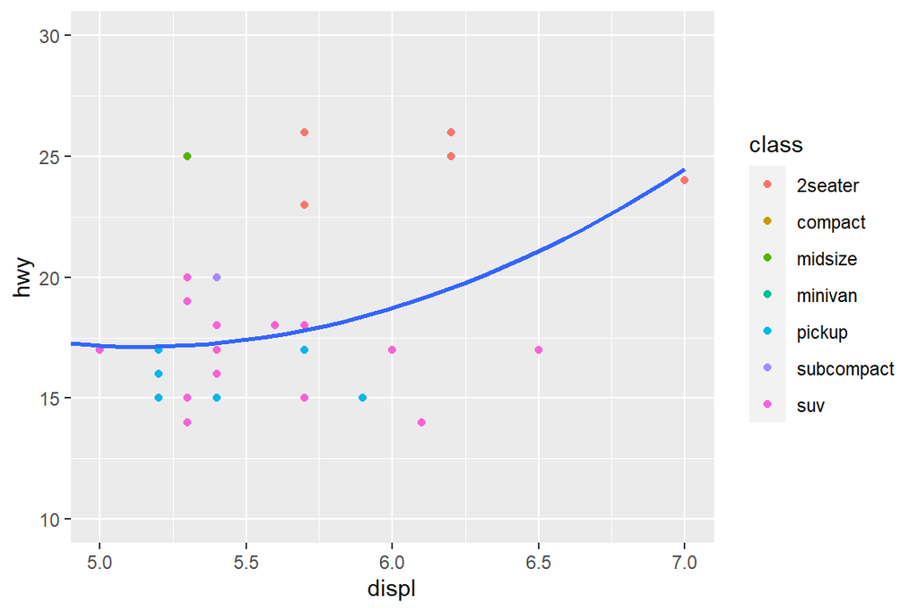

```r
    ggplot(mpg, mapping = aes(displ, hwy)) +
      geom_point(aes(color = class)) +
      geom_smooth() +
      coord_cartesian(xlim = c(5, 7), ylim = c(10, 30))
```

Você também pode definir o `limits` em escalas individuais.

- Reduzir os limites é basicamente equivalente a subconfigurar os dados.
- Geralmente, é mais útil se você deseja *expandir* os limites, por exemplo, para corresponder as escalas em diferentes gráficos.
- Por exemplo, se extrairmos duas classes de carros e os plotarmos separadamente, será difícil comparar os gráficos porque todas as três escalas (o eixo x, o eixo y e a estética de cores) têm intervalos diferentes.

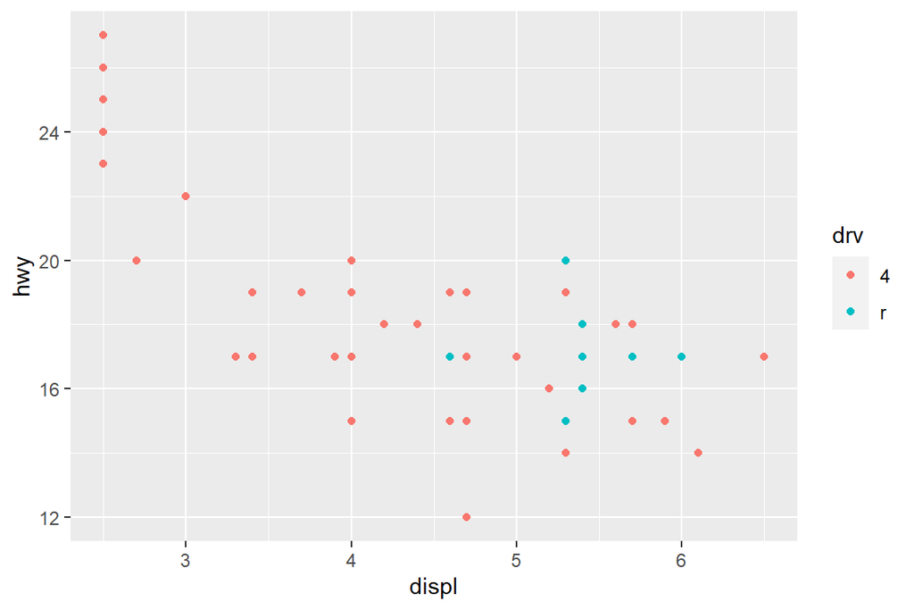

```r
    suv <- mpg %>% filter(class == "suv")
    compact <- mpg %>% filter(class == "compact")

    ggplot(suv, aes(displ, hwy, colour = drv)) +
      geom_point()
```

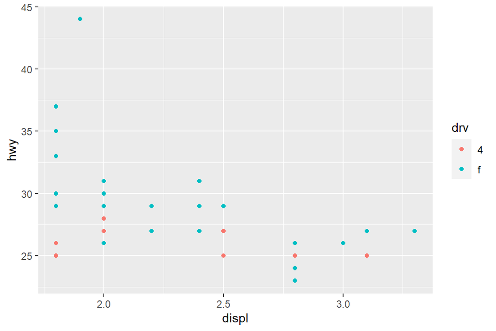

```r
    ggplot(compact, aes(displ, hwy, colour = drv)) +
      geom_point()
```

Uma maneira de superar esse problema é compartilhar escalas em vários gráficos, treinando as escalas com os `limits` dados completos.

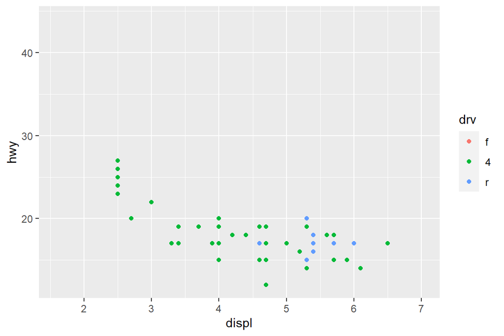

```r
    x_scale <- scale_x_continuous(limits = range(mpg$displ))
    y_scale <- scale_y_continuous(limits = range(mpg$hwy))
    col_scale <- scale_colour_discrete(limits = unique(mpg$drv))

    ggplot(suv, aes(displ, hwy, colour = drv)) +
      geom_point() +
      x_scale +
      y_scale +
      col_scale
```

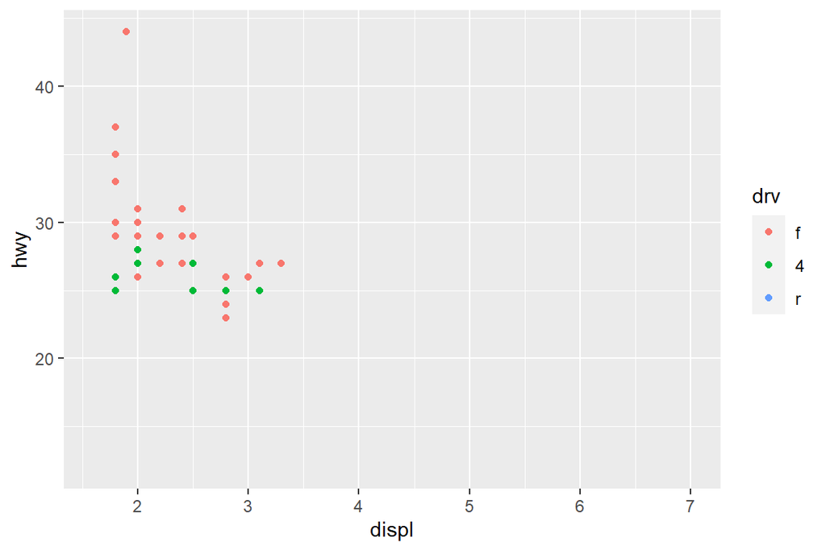

```r
    ggplot(compact, aes(displ, hwy, colour = drv)) +
      geom_point() +
      x_scale +
      y_scale +
      col_scale
```

Nesse caso em particular, você poderia simplesmente usar a facetação, mas essa técnica é útil de maneira mais geral, se, por exemplo, você quiser espalhar gráficos por várias páginas de um relatório.

## Temas

Por fim, você pode personalizar os elementos não-dados do seu gráfico com um tema:

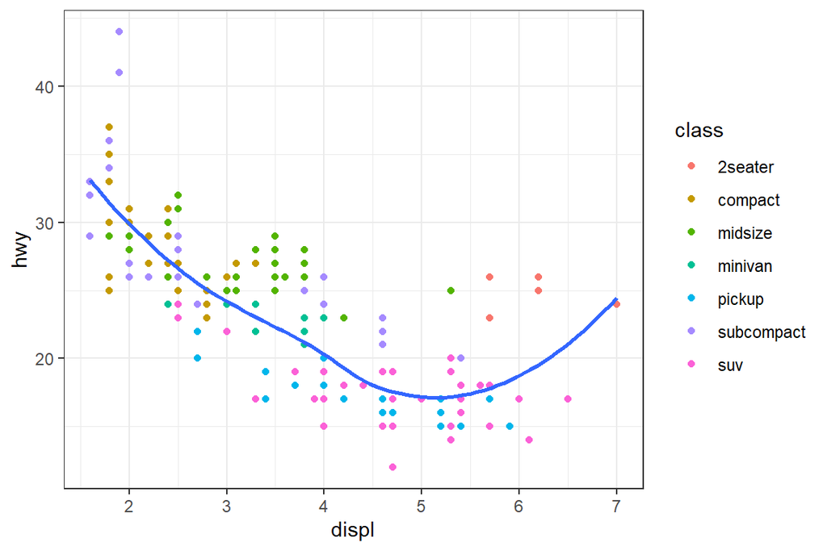

```r
    ggplot(mpg, aes(displ, hwy)) +
      geom_point(aes(color = class)) +
      geom_smooth(se = FALSE) +
      theme_bw()
```

O ggplot2 inclui oito temas por padrão, conforme mostrado na Figura abaixo.

- Muitos outros estão incluídos em pacotes complementares como **ggthemes** ( https://github.com/jrnold/ggthemes ), de Jeffrey Arnold.

[figure not shown]

Os oito temas integrados ao ggplot2.

Muitas pessoas se perguntam por que o tema padrão tem um fundo cinza.

- Esta foi uma escolha deliberada porque coloca os dados adiante enquanto ainda torna as linhas de grade visíveis.
- As linhas de grade brancas são visíveis (o que é importante porque ajudam significativamente nos julgamentos de posição), mas têm pouco impacto visual e podemos facilmente ajustá-las.
- O fundo cinza dá à plotagem uma cor tipográfica semelhante ao texto, garantindo que os gráficos se encaixem no fluxo de um documento sem saltar com um fundo branco brilhante.
- Por fim, o fundo cinza cria um campo de cor contínuo que garante que o plot seja percebido como uma entidade visual única.

### Existem outros temas?

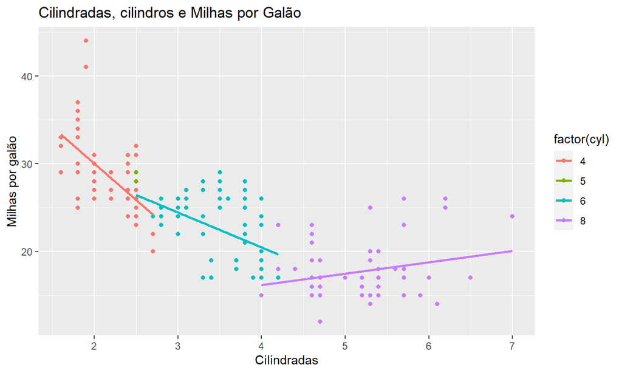

```r
library(ggthemes)
library(gridExtra)

grafico <- ggplot(mpg, aes(displ, hwy, col=factor(cyl))) + geom_point() +
  geom_smooth(method = "lm", se = F) + ggtitle("Cilindradas, cilindros e Milhas por Galão") +
  ylab("Milhas por galão") + xlab("Cilindradas")

# Grafico original
grafico
```

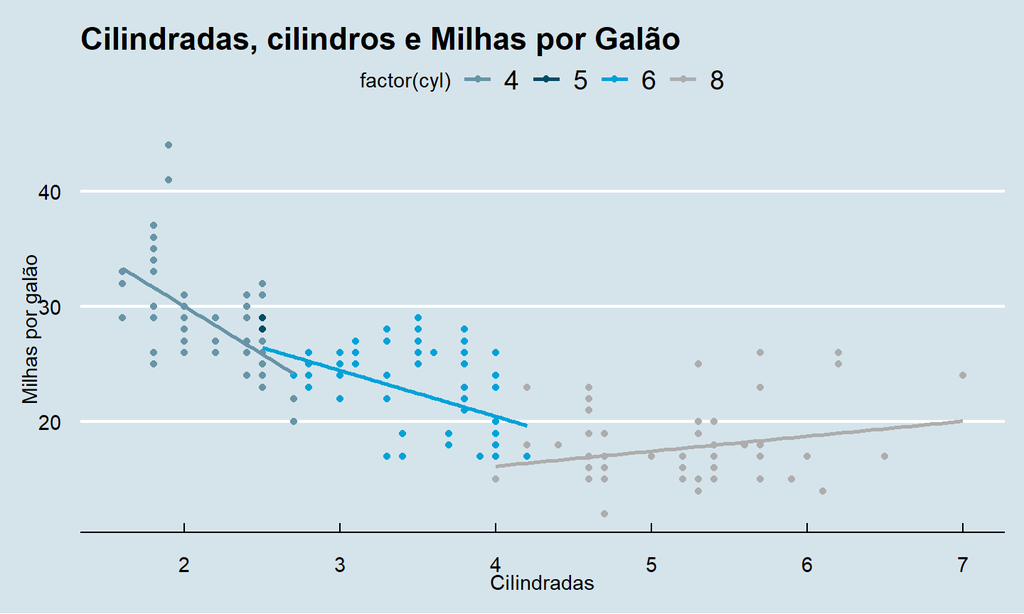

```r
# Tema "The Economist" com respectiva escala de cores
grafico + theme_economist() + scale_color_economist()
```

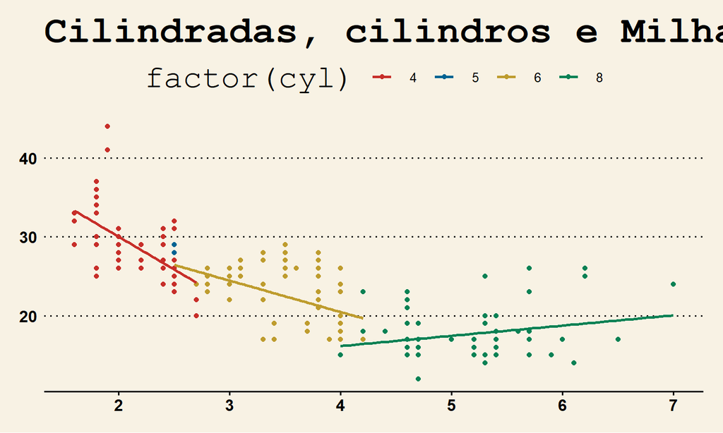

```r
# Tema "The Wall Street Journal" com respectiva escala de cores
grafico + theme_wsj() + scale_color_wsj()
```

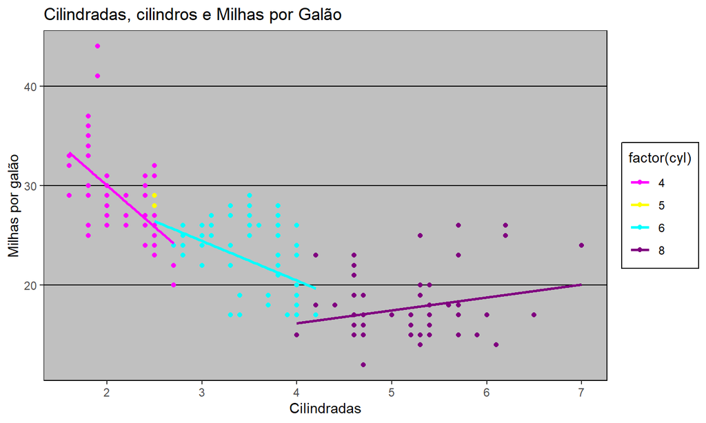

```r
# Tema "Excel" com respectiva escala de cores
grafico + theme_excel() + scale_color_excel()
```

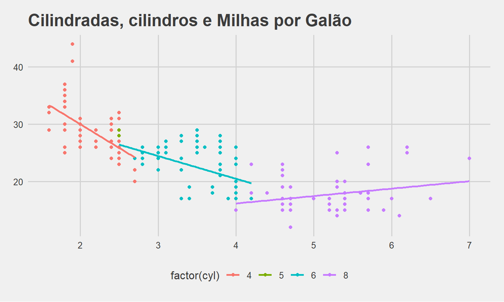

```r
# Tema "fivethirtyeight"
grafico + theme_fivethirtyeight()
```

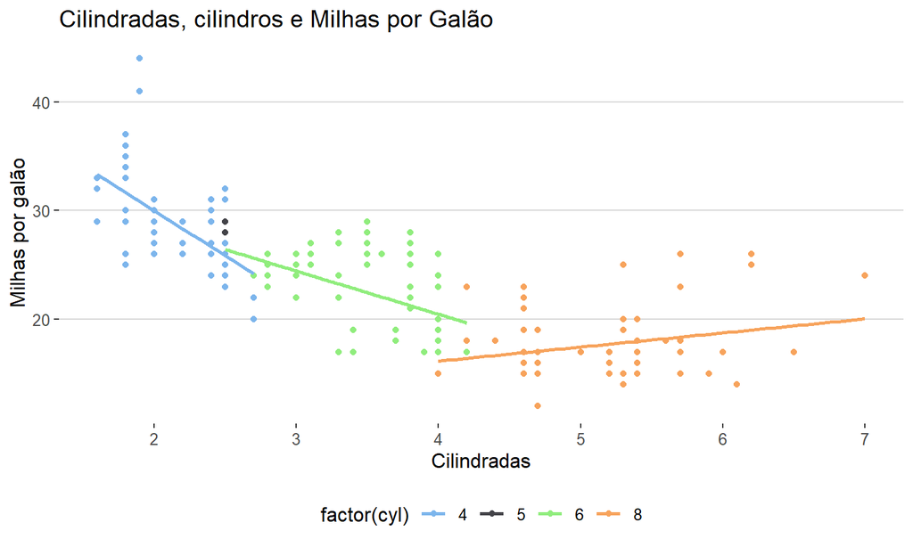

```r
# Tema "highcharts" com respectiva escala de cores
grafico + theme_hc()  + scale_color_hc()
```

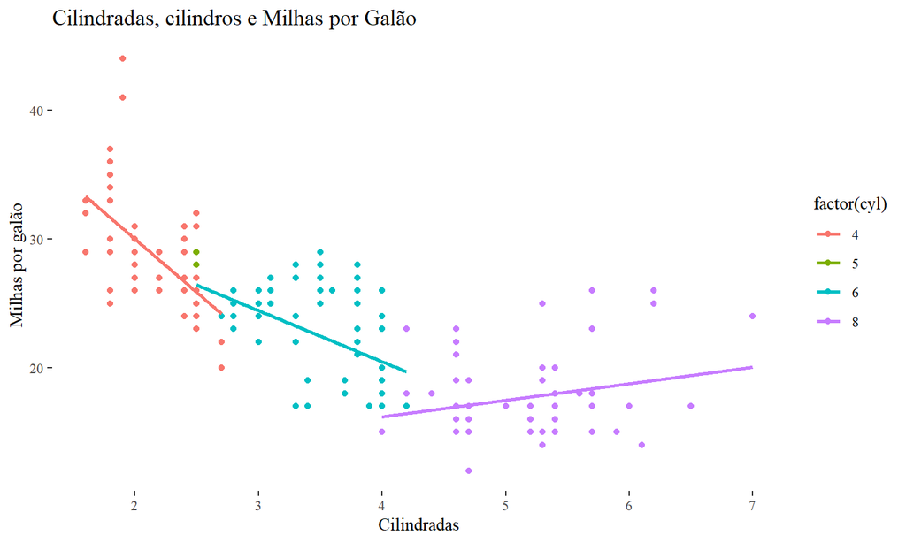

```r
# Tema "Tufte"
grafico + theme_tufte()
```

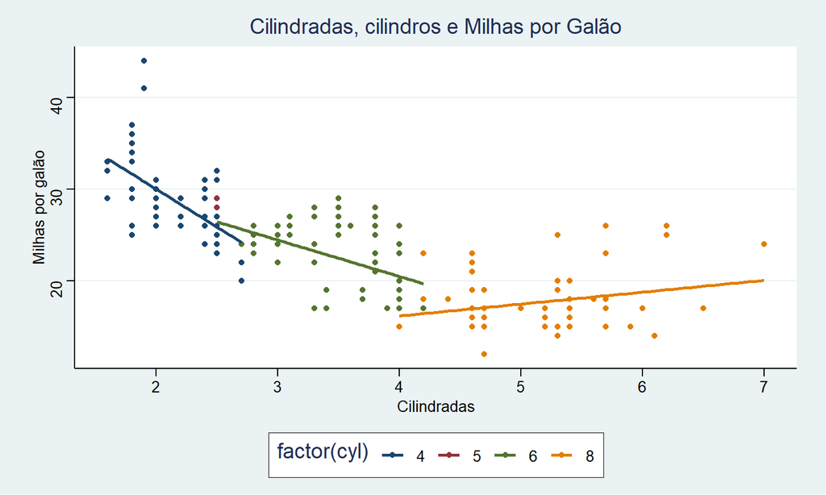

```r
# Tema "Stata" com respectiva escala de cores
grafico + theme_stata() + scale_color_stata()
```

### Agrupando gráficos em uma única figura

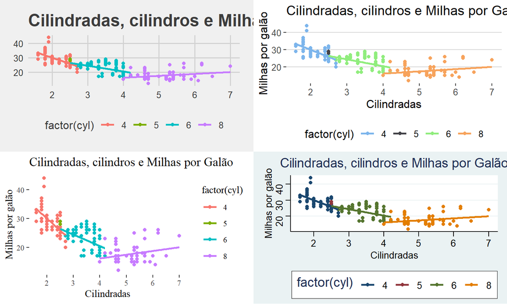

```r
## Para colocar varios graficos juntos
g1 <- grafico + theme_fivethirtyeight()
g2 <- grafico + theme_hc() + scale_color_hc()
g3 <- grafico + theme_tufte()
g4 <- grafico + theme_stata() + scale_color_stata()
grid.arrange(g1, g2, g3, g4)
```

## Salvando seus gráficos

- [`ggsave()`](https://ggplot2.tidyverse.org/reference/ggsave.html) irá salvar o gráfico mais recente no disco:

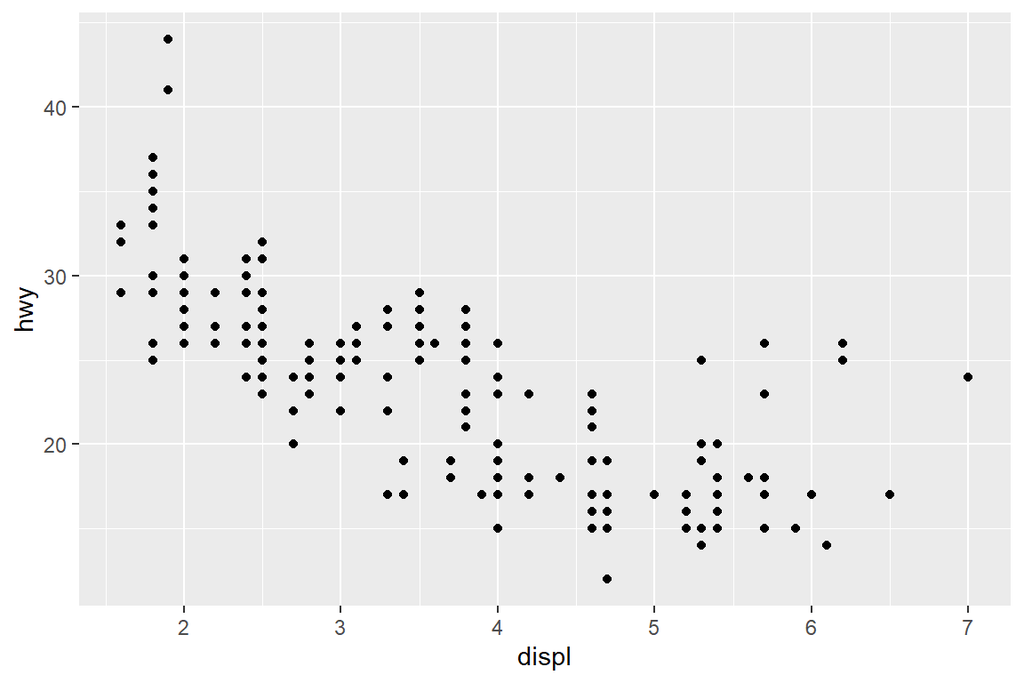

```r
    ggplot(mpg, aes(displ, hwy)) + geom_point()
```

```r
    ggsave("my-plot.pdf")
```

## Aprendendo mais

O melhor lugar para aprender mais é o livro ggplot2: [*ggplot2: Elegant graphics for data analysis*](https://amzn.com/331924275X).

Outro ótimo recurso é a galeria de extensões ggplot2 https://exts.ggplot2.tidyverse.org/gallery/.

- Este site lista muitos dos pacotes que estendem o ggplot2 com novas geometrias e escalas.
- É um ótimo lugar para começar se você está tentando fazer algo que parece difícil com o ggplot2.